# Part I - (Ford GoBike System Data)

## by (Victoria Adenike Areola)

## Introduction

> This data set includes information about individual rides made in a bike-sharing system covering the greater San Francisco Bay area.

## Preliminary Wrangling

```python
# import all packages and set plots to be embedded inline
import numpy as np
import pandas as pd
import matplotlib.pyplot as plt
import seaborn as sb

%matplotlib inline
```

```python
#Load dataset into a pandas dataframe
fordgobike = pd.read_csv('fordgobike-tripdata.csv')
```

```python
# Display dataset for visual exploration of dataset
fordgobike.head()
```

|  | duration_sec | start_time | end_time | start_station_id | start_station_name | start_station_latitude | start_station_longitude | end_station_id | end_station_name | end_station_latitude | end_station_longitude | bike_id | user_type | member_birth_year | member_gender | bike_share_for_all_trip |
| --- | --- | --- | --- | --- | --- | --- | --- | --- | --- | --- | --- | --- | --- | --- | --- | --- |
| 0 | 52185 | 32:10.1 | 01:56.0 | 21.0 | Montgomery St BART Station (Market St at 2nd St) | 37.789625 | -122.400811 | 13.0 | Commercial St at Montgomery St | 37.794231 | -122.402923 | 4902 | Customer | 1984.0 | Male | No |
| 1 | 42521 | 53:21.8 | 42:03.1 | 23.0 | The Embarcadero at Steuart St | 37.791464 | -122.391034 | 81.0 | Berry St at 4th St | 37.775880 | -122.393170 | 2535 | Customer | NaN | NaN | No |
| 2 | 61854 | 13:13.2 | 24:08.1 | 86.0 | Market St at Dolores St | 37.769305 | -122.426826 | 3.0 | Powell St BART Station (Market St at 4th St) | 37.786375 | -122.404904 | 5905 | Customer | 1972.0 | Male | No |
| 3 | 36490 | 54:26.0 | 02:36.8 | 375.0 | Grove St at Masonic Ave | 37.774836 | -122.446546 | 70.0 | Central Ave at Fell St | 37.773311 | -122.444293 | 6638 | Subscriber | 1989.0 | Other | No |
| 4 | 1585 | 54:18.5 | 20:44.1 | 7.0 | Frank H Ogawa Plaza | 37.804562 | -122.271738 | 222.0 | 10th Ave at E 15th St | 37.792714 | -122.248780 | 4898 | Subscriber | 1974.0 | Male | Yes |

```python
""" Create a new column 'age' derived from the column 'member_birth_year' to
see the age distribution of fordgobike users and for other explorations.
"""
fordgobike['age']= fordgobike.apply(lambda row: 2022 - row.member_birth_year, axis=1)
mean = fordgobike['age'].mean()
fordgobike['age'].fillna(mean, inplace=True)
fordgobike['age']= fordgobike['age'].astype(int)
fordgobike.head(1)
```

|  | duration_sec | start_time | end_time | start_station_id | start_station_name | start_station_latitude | start_station_longitude | end_station_id | end_station_name | end_station_latitude | end_station_longitude | bike_id | user_type | member_birth_year | member_gender | bike_share_for_all_trip | age |
| --- | --- | --- | --- | --- | --- | --- | --- | --- | --- | --- | --- | --- | --- | --- | --- | --- | --- |
| 0 | 52185 | 32:10.1 | 01:56.0 | 21.0 | Montgomery St BART Station (Market St at 2nd St) | 37.789625 | -122.400811 | 13.0 | Commercial St at Montgomery St | 37.794231 | -122.402923 | 4902 | Customer | 1984.0 | Male | No | 38 |

```python
#create new column 'distance' using the coordinate of each station
from math import radians, cos, sin, asin, sqrt
def haversine(start_station_longitude, start_station_latitude, end_station_longitude, end_station_latitude):

#Calculate the great circle distance between two points on the earth (specified in decimal degrees)

    # convert decimal degrees to radians
    start_station_longitude, start_station_latitude, end_station_longitude, end_station_latitude = map(radians, [start_station_longitude, start_station_latitude, end_station_longitude, end_station_latitude])
    # haversine formula
    dlon = end_station_longitude - start_station_longitude
    dlat = end_station_latitude - start_station_latitude
    a = sin(dlat/2)**2 + cos(start_station_latitude) * cos(end_station_latitude) * sin(dlon/2)**2
    c = 2 * asin(sqrt(a))
    # Radius of earth in kilometers is 6371
    distance = 6371* c
    return distance


fordgobike['distance'] = fordgobike.apply(lambda x: haversine(x['start_station_longitude'], x['start_station_latitude'], x['end_station_longitude'], x['end_station_latitude']), axis=1)
```

```python
#confirm distance column created
fordgobike.head(10)
```

|  | duration_sec | start_time | end_time | start_station_id | start_station_name | start_station_latitude | start_station_longitude | end_station_id | end_station_name | end_station_latitude | end_station_longitude | bike_id | user_type | member_birth_year | member_gender | bike_share_for_all_trip | age | distance |
| --- | --- | --- | --- | --- | --- | --- | --- | --- | --- | --- | --- | --- | --- | --- | --- | --- | --- | --- |
| 0 | 52185 | 32:10.1 | 01:56.0 | 21.0 | Montgomery St BART Station (Market St at 2nd St) | 37.789625 | -122.400811 | 13.0 | Commercial St at Montgomery St | 37.794231 | -122.402923 | 4902 | Customer | 1984.0 | Male | No | 38 | 0.544709 |
| 1 | 42521 | 53:21.8 | 42:03.1 | 23.0 | The Embarcadero at Steuart St | 37.791464 | -122.391034 | 81.0 | Berry St at 4th St | 37.775880 | -122.393170 | 2535 | Customer | NaN | NaN | No | 37 | 1.742999 |
| 2 | 61854 | 13:13.2 | 24:08.1 | 86.0 | Market St at Dolores St | 37.769305 | -122.426826 | 3.0 | Powell St BART Station (Market St at 4th St) | 37.786375 | -122.404904 | 5905 | Customer | 1972.0 | Male | No | 50 | 2.704543 |
| 3 | 36490 | 54:26.0 | 02:36.8 | 375.0 | Grove St at Masonic Ave | 37.774836 | -122.446546 | 70.0 | Central Ave at Fell St | 37.773311 | -122.444293 | 6638 | Subscriber | 1989.0 | Other | No | 33 | 0.260741 |
| 4 | 1585 | 54:18.5 | 20:44.1 | 7.0 | Frank H Ogawa Plaza | 37.804562 | -122.271738 | 222.0 | 10th Ave at E 15th St | 37.792714 | -122.248780 | 4898 | Subscriber | 1974.0 | Male | Yes | 48 | 2.409305 |
| 5 | 1793 | 49:58.6 | 19:51.8 | 93.0 | 4th St at Mission Bay Blvd S | 37.770407 | -122.391198 | 323.0 | Broadway at Kearny | 37.798014 | -122.405950 | 5200 | Subscriber | 1959.0 | Male | No | 63 | 3.332201 |
| 6 | 1147 | 55:35.1 | 14:42.6 | 300.0 | Palm St at Willow St | 37.317298 | -121.884995 | 312.0 | San Jose Diridon Station | 37.329732 | -121.901782 | 3803 | Subscriber | 1983.0 | Female | No | 39 | 2.028551 |
| 7 | 1615 | 41:06.8 | 08:02.8 | 10.0 | Washington St at Kearny St | 37.795393 | -122.404770 | 127.0 | Valencia St at 21st St | 37.756708 | -122.421025 | 6329 | Subscriber | 1989.0 | Male | No | 33 | 4.532567 |
| 8 | 1570 | 41:48.8 | 07:59.7 | 10.0 | Washington St at Kearny St | 37.795393 | -122.404770 | 127.0 | Valencia St at 21st St | 37.756708 | -122.421025 | 6548 | Subscriber | 1988.0 | Other | No | 34 | 4.532567 |
| 9 | 1049 | 49:47.7 | 07:17.0 | 19.0 | Post St at Kearny St | 37.788975 | -122.403452 | 121.0 | Mission Playground | 37.759210 | -122.421339 | 6488 | Subscriber | 1992.0 | Male | No | 30 | 3.664101 |

```python
#dataset overview
print(fordgobike.shape)
print(fordgobike.dtypes)
fordgobike.head(1)
```

```
(183412, 18)
duration_sec                 int64
start_time                  object
end_time                    object
start_station_id           float64
start_station_name          object
start_station_latitude     float64
start_station_longitude    float64
end_station_id             float64
end_station_name            object
end_station_latitude       float64
end_station_longitude      float64
bike_id                      int64
user_type                   object
member_birth_year          float64
member_gender               object
bike_share_for_all_trip     object
age                          int64
distance                   float64
dtype: object
```

|  | duration_sec | start_time | end_time | start_station_id | start_station_name | start_station_latitude | start_station_longitude | end_station_id | end_station_name | end_station_latitude | end_station_longitude | bike_id | user_type | member_birth_year | member_gender | bike_share_for_all_trip | age | distance |
| --- | --- | --- | --- | --- | --- | --- | --- | --- | --- | --- | --- | --- | --- | --- | --- | --- | --- | --- |
| 0 | 52185 | 32:10.1 | 01:56.0 | 21.0 | Montgomery St BART Station (Market St at 2nd St) | 37.789625 | -122.400811 | 13.0 | Commercial St at Montgomery St | 37.794231 | -122.402923 | 4902 | Customer | 1984.0 | Male | No | 38 | 0.544709 |

```python
# Descriptive statistics of numeric variables
fordgobike.describe()
```

|  | duration_sec | start_station_id | start_station_latitude | start_station_longitude | end_station_id | end_station_latitude | end_station_longitude | bike_id | member_birth_year | age | distance |
| --- | --- | --- | --- | --- | --- | --- | --- | --- | --- | --- | --- |
| count | 183412.000000 | 183215.000000 | 183412.000000 | 183412.000000 | 183215.000000 | 183412.000000 | 183412.000000 | 183412.000000 | 175147.000000 | 183412.000000 | 183412.000000 |
| mean | 726.078435 | 138.590427 | 37.771223 | -122.352664 | 136.249123 | 37.771427 | -122.352250 | 4472.906375 | 1984.806437 | 37.184841 | 1.690659 |
| std | 1794.389780 | 111.778864 | 0.099581 | 0.117097 | 111.515131 | 0.099490 | 0.116673 | 1664.383394 | 10.116689 | 9.886200 | 1.097589 |
| min | 61.000000 | 3.000000 | 37.317298 | -122.453704 | 3.000000 | 37.317298 | -122.453704 | 11.000000 | 1878.000000 | 21.000000 | 0.000000 |
| 25% | 325.000000 | 47.000000 | 37.770083 | -122.412408 | 44.000000 | 37.770407 | -122.411726 | 3777.000000 | 1980.000000 | 30.000000 | 0.910955 |
| 50% | 514.000000 | 104.000000 | 37.780760 | -122.398285 | 100.000000 | 37.781010 | -122.398279 | 4958.000000 | 1987.000000 | 35.000000 | 1.430737 |
| 75% | 796.000000 | 239.000000 | 37.797280 | -122.286533 | 235.000000 | 37.797320 | -122.288045 | 5502.000000 | 1992.000000 | 41.000000 | 2.225684 |
| max | 85444.000000 | 398.000000 | 37.880222 | -121.874119 | 398.000000 | 37.880222 | -121.874119 | 6645.000000 | 2001.000000 | 144.000000 | 69.469241 |

```python
#Checking unique values in the dataset
fordgobike.nunique()
```

```
duration_sec                4752
start_time                 35783
end_time                   35767
start_station_id             329
start_station_name           329
start_station_latitude       334
start_station_longitude      335
end_station_id               329
end_station_name             329
end_station_latitude         335
end_station_longitude        335
bike_id                     4646
user_type                      2
member_birth_year             75
member_gender                  3
bike_share_for_all_trip        2
age                           75
distance                   13939
dtype: int64
```

```python
#Checking columns with null value
fordgobike.isnull().sum()
```

```
duration_sec                  0
start_time                    0
end_time                      0
start_station_id            197
start_station_name          197
start_station_latitude        0
start_station_longitude       0
end_station_id              197
end_station_name            197
end_station_latitude          0
end_station_longitude         0
bike_id                       0
user_type                     0
member_birth_year          8265
member_gender              8265
bike_share_for_all_trip       0
age                           0
distance                      0
dtype: int64
```

```python
#Checking ovarall infomation of the dataset
fordgobike.info()
```

```
<class 'pandas.core.frame.DataFrame'>
RangeIndex: 183412 entries, 0 to 183411
Data columns (total 18 columns):
duration_sec               183412 non-null int64
start_time                 183412 non-null object
end_time                   183412 non-null object
start_station_id           183215 non-null float64
start_station_name         183215 non-null object
start_station_latitude     183412 non-null float64
start_station_longitude    183412 non-null float64
end_station_id             183215 non-null float64
end_station_name           183215 non-null object
end_station_latitude       183412 non-null float64
end_station_longitude      183412 non-null float64
bike_id                    183412 non-null int64
user_type                  183412 non-null object
member_birth_year          175147 non-null float64
member_gender              175147 non-null object
bike_share_for_all_trip    183412 non-null object
age                        183412 non-null int64
distance                   183412 non-null float64
dtypes: float64(8), int64(3), object(7)
memory usage: 25.2+ MB
```

```python
# Checking for duplicate
sum(fordgobike.duplicated())
```

```
0
```

```python
#checking how many categories of user_type are available
fordgobike['user_type'].nunique()
```

```
2
```

```python
#checking how many categories of member_gender are available
fordgobike['member_gender'].nunique()
```

```
3
```

```python
#check how many categories of bike_share_for_all_trip are available
fordgobike['bike_share_for_all_trip'].nunique()
```

```
2
```

### What is the structure of your dataset?

There are 183412 rows and 18 columns (duration_sec, start_time, end_time, start_station_id, start_station_name, start_station_latitude, start_station_longitude, end_station_id, end_station_name, end_station_latitude, end_station_longitude, bike_id, user_type, member_birth_year, member_gender, bike_share_for_all_trip, age, distance) in the fordgobike dataset. 11 of the columns are numerical while three variables are categorical such as (user_type, member_gender and bike_share_for_all_trip).

- User_type has two categories: Subscribers and Customers
- Member has three categories: Male, Female and others
- Bike_share_for_all_trip has two categories:Yes and No
- I performed and operation on the member_birth_year column to production the age of each member, which I did by subtracting their year from the present year(2022). I used fillna to cater for missing data and checked the distribution.
- I also used the coordinate of each stations to get the distance cover in Kilometer.

### What is/are the main feature(s) of interest in your dataset?

- I am interested in finding out the gender that spend the most time in seconds of bike usage and the distance covered from one location to another.
- I am also interested in finding out which gender patronises the most, to see if they prefer bike for all trip and to see if they are subcriber or not.
- I want to findout if the age and gender of users affect the amount of time spent per trip.
- I want to also see if age and gender of users affect the distance cover per trip.

### What features in the dataset do you think will help support your investigation into your feature(s) of interest?

- I expect that the following features of the dataset will help in my investigation: duration_sec, user_type, member_gender, bike_share_for_all_trip, age, distance.

## Univariate Exploration

- Which type of users patronizes the fordgobike-sharing system the most?

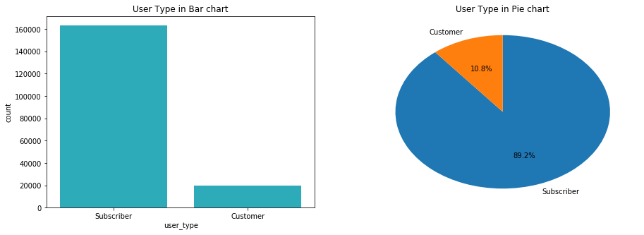

```python
#Checking the varoius types of bike users.

base_color = sb.color_palette()[9]
plt.figure (figsize=[15,5])

plt.subplot(1,2,1)
user_count= fordgobike['user_type'].value_counts()
user_order= user_count.index
sb.countplot(data=fordgobike, x= 'user_type', color=base_color, order = user_order)
plt.title('User Type in Bar chart');

plt.subplot(1,2,2)
sorted_count= fordgobike['user_type'].value_counts()
plt.pie(sorted_count, labels = sorted_count.index, autopct='%1.1f%%', startangle = 90, counterclock = False)
plt.title('User Type in Pie chart');
```

There are about 89.2% of users who are subcribers and 10.8% of users who are customers. Which shows that most of the Fordgobike users subscribe to Fordgobike-sharing system.

- Which gender patronizes fordgobike-sharing system the most?

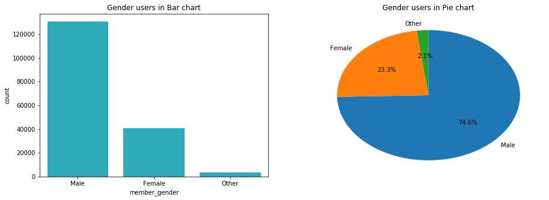

```python
#Checking the gender that has high usage of bike
plt.figure (figsize=[15,5])

plt.subplot(1,2,1)
gender_count= fordgobike['member_gender'].value_counts()
gender_order= gender_count.index
sb.countplot(data=fordgobike, x= 'member_gender', color=base_color, order = gender_order)
plt.title('Gender users in Bar chart');

plt.subplot(1,2,2)
sorted_count= fordgobike['member_gender'].value_counts()
plt.pie(sorted_count, labels = sorted_count.index, autopct='%1.1f%%', startangle = 90, counterclock = False)
plt.title('Gender users in Pie chart');
```

74.6% of Male patronizes fordgobike-sharing system, 23.3% of female patronizes fordgobike-sharing system and 2.1% other gender patronizes fordgobike-sharing system. This clearly shows that the male gender patronizes Ford go bike more than other gender.

- Do user prefer to use bike for all their trip?

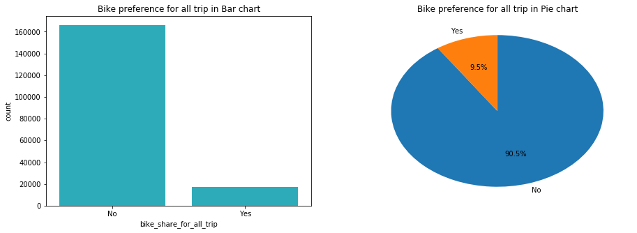

```python
#Checking if bike is the preference for all trip
plt.figure (figsize=[15,5])

plt.subplot(1,2,1)
trip_count= fordgobike['bike_share_for_all_trip'].value_counts()
trip_order= trip_count.index
sb.countplot(data=fordgobike, x= 'bike_share_for_all_trip', color=base_color, order = trip_order)
plt.title('Bike preference for all trip in Bar chart');

plt.subplot(1,2,2)
sorted_count= fordgobike['bike_share_for_all_trip'].value_counts()
plt.pie(sorted_count, labels = sorted_count.index, autopct='%1.1f%%', startangle = 90, counterclock = False)
plt.title('Bike preference for all trip in Pie chart');
```

9.5% of the fordgobike patronizers pefer to use bike for all their trips while 90.5% of the patronizer might prefer other means for their trip.

- What is the highest peroid of time spent on trips?

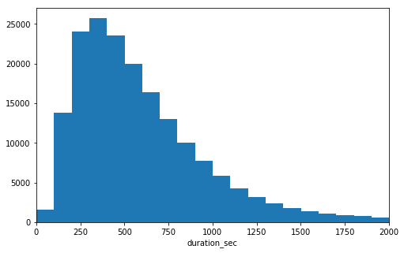

```python
# Checking the distribution of duration in sec, to investigate the amount of time mostly spent during the trips.
plt.figure(figsize=[8, 5])
bins = np.arange(1, 85444, 100)
plt.hist(data=fordgobike, x='duration_sec', bins=bins)
plt.xlim(0,2000)
plt.xlabel('duration_sec');
```

In the duration_sec, the distribution is right-skewed and it has outliers. I used xlim to set the limit. It is unimodal, the amount of time spent the most in seconds fall between 250 and 750.

- Which age range patronizes fordgobike-sharing system the most?

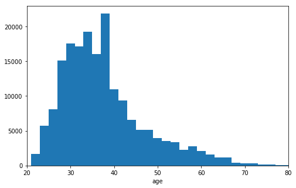

```python
# Checking the distribution of age, to see the age range that patronizes fordgobike-sharing system the most.
plt.figure(figsize=[8, 5])
bins = np.arange(1, 144, 2)
plt.hist(data=fordgobike, x='age', bins=bins)
plt.xlim(20,80)
plt.xlabel('age');
```

The age distribution of the users of the fordgobike is right-skewed. It has outliers, so I set the limit to 20,80. It appears to be unimodal, presenting people between age of 30 to 40 to be the highest patronizers.

- What is the distribution of distance covered in the dataset?

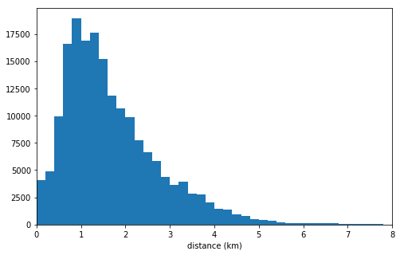

```python
# Checking the distribution of distance to see the distance covered the most.
plt.figure(figsize=[8, 5])
bins = np.arange(0, 69+0.2, 0.2)
plt.hist(data=fordgobike, x='distance', bins =bins)
plt.xlim(0,8)
plt.xlabel('distance (km)');
```

The distribution of the distance based on the coordinates of each station for fordgobike is right-skewed. It has outliers, so I set the limit to 0,8. It appears to be unimodal presenting that most users covered distance between 0.5km to 2.5km.

### Discuss the distribution(s) of your variable(s) of interest. Were there any unusual points? Did you need to perform any transformations?

> The time duration in seconds has outliers, so I used xlim to set its limit. The highest duration was between 250 and 750. The age distribution has outliers, I set the limit. The highest duration falls between age 30 and 40. The distance in km has outliers, I set the xlim. The distribution shows that most of the users covered distance between 0.5km to 2.5km.

### Of the features you investigated, were there any unusual distributions? Did you perform any operations on the data to tidy, adjust, or change the form of the data? If so, why did you do this?

> I did not perform any operation to tidy or adjust the form of the data. Overall I set limit to cater for outliers in the data.

## Bivariate Exploration

```python
#Assigning Numeric and categorical variables
numeric_vars = ['duration_sec','start_station_id','start_station_latitude','start_station_longitude','end_station_id','end_station_latitude','end_station_longitude','bike_id', 'member_birth_year','age', 'distance']
categoric_vars = ['user_type','member_gender','bike_share_for_all_trip']
```

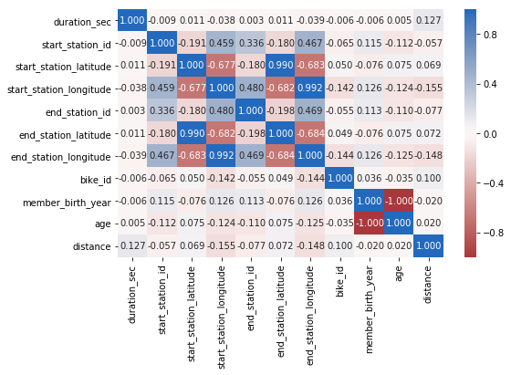

```python
# correlation plot
plt.figure(figsize = [8, 5])
sb.heatmap(fordgobike[numeric_vars].corr(), annot = True, fmt = '.3f', cmap = 'vlag_r', center = 0)
plt.show()
```

```
fordgobike.shape= (183412, 18)
fordgobike_samp.shape= (300, 18)
```

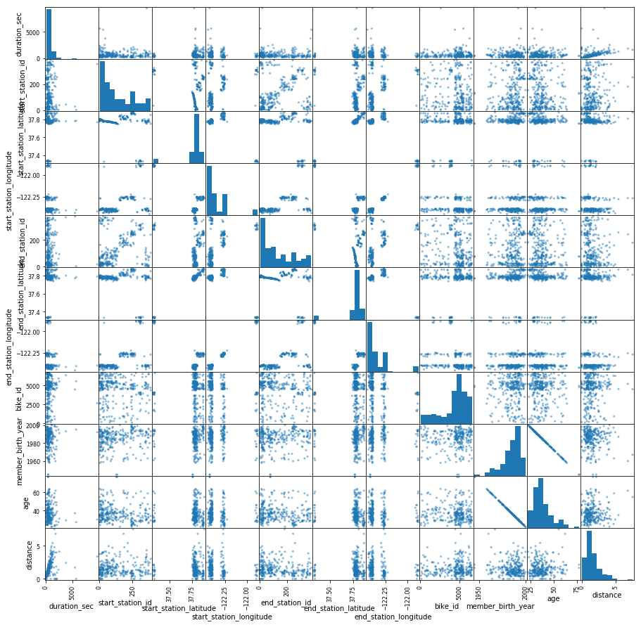

```python
#plot matrix: sample 300 fordgobike for clarity of plots
print("fordgobike.shape=",fordgobike.shape)
fordgobike_samp = fordgobike.sample(n=300, replace = False)
print("fordgobike_samp.shape=",fordgobike_samp.shape)
pd.plotting.scatter_matrix(fordgobike_samp, figsize=(15,15));
```

- What is the relationship between gender and time spent?

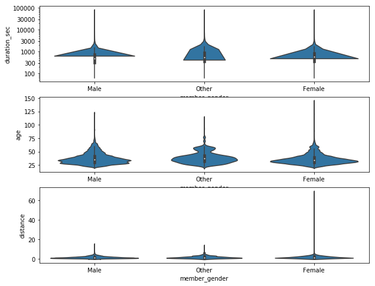

```python
#violin plot of member gender and numeric variables
base_color = sb.color_palette()[0]
plt.figure(figsize = [10, 8])

plt.subplot(3, 1, 1)
bins= 10**np.arange(1,5+1.0,1.0)
ticks=[100,300,1000,3000,10000,30000, 100000]
labels=['{}'.format(v)for v in ticks]
sb.violinplot(data=fordgobike, x='member_gender', y='duration_sec', color= base_color, bins=bins)
plt.yscale('log');
plt.yticks(ticks,labels);

plt.subplot(3, 1, 2)
sb.violinplot(data=fordgobike, x='member_gender', y='age', color= base_color)

plt.subplot(3, 1, 3)
sb.violinplot(data=fordgobike, x='member_gender', y='distance', color= base_color)
```

The violin plot for duration_sec shows that the male duration distribution falls above the median point, while for the 'other' member_gender most of its density fall around the median and for the female distribution most of the density is slightly above the median. The three gender types have almost equal upper limit. The age distribution for the gender types also showed that females have the highest age extremes and also the highest age density around the median. The distance distribution for the gender types shows that females have highest extreme distance coverage whereas males have the greatest distance covered density around the median value.

- What is the relationship between user_type and member_gender?

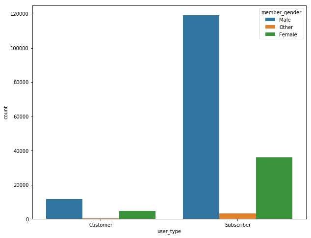

```python
#cluster bar chart of user_type and member_gender
plt.figure(figsize = [10, 8])
sb.countplot(data=fordgobike, x='user_type', hue='member_gender');
```

The cluster bar chart shown above indicates that the gender with the highest subscription and patronage without subscription (customers) is the male gender.

- What is the relationship between gender and bike_share_for_all_trip

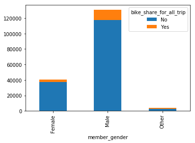

```python
#cluster bar chart of member_gender and bike_share_for_all_trip
plt.figure(figsize = [10, 8])
fordgobike.groupby(['member_gender', 'bike_share_for_all_trip']).size().unstack().plot(kind='bar', stacked=True);
```

The stacked bar show that the ratio of no in female is more than the ration of no in male gender

- What is the relationship between duration spent on trip and age?

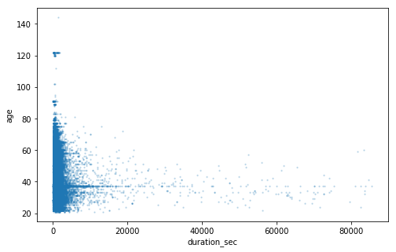

```python
# Scatter plot to check relationship between 'duration_sec' and 'age'
plt.figure(figsize=[8, 5])
plt.scatter(data= fordgobike, x='duration_sec',y='age', alpha=0.2,s=2)
plt.xlabel('duration_sec')
plt.ylabel('age');
```

There is no correllation between duration_sec and age of the users. This shows that time spent on cycling did not change based on age.

- What is the relationship between age and distance covered

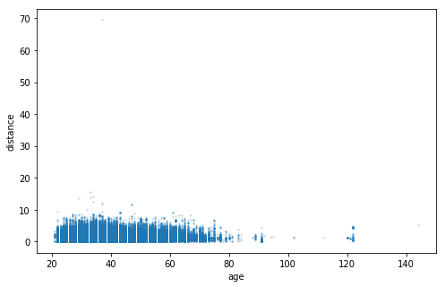

```python
# Scatter plot to check relationship between 'distance' and 'age'
plt.figure(figsize=[8, 5])
plt.scatter(data= fordgobike, x='age',y='distance',alpha=0.2,s=2)
plt.xlabel('age')
plt.ylabel('distance');
```

The above scatter plot shows no correllation between age and distance. Again, as expected with reference to the correlation of duration and age, distance covered did not change in relation to the age of users.

- What is the relationship between time spent and distance covered?

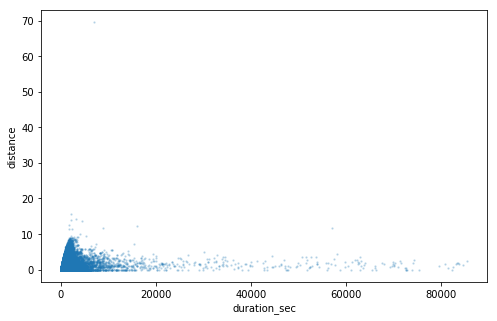

```python
# Scatter plot to check relationship between 'duration_sec' and 'distance'
plt.figure(figsize=[8, 5])
plt.scatter(data= fordgobike, x='duration_sec',y='distance',alpha=0.2,s=2)
plt.xlabel('duration_sec')
plt.ylabel('distance');
```

- What is the relationship between user_type and member_gender, member_gender and bike_share_for_all_trip, bike_share_for_all_trip and user_type?

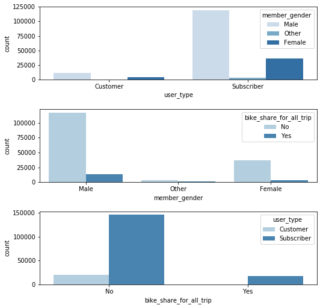

```python
#stack bar for categorical variable
plt.figure(figsize=[8, 8])
plt.subplots_adjust(left=0.1, bottom=0.1, right=0.9, top=0.9, wspace=0.4, hspace=0.4)

# subplot 1: user_type vs member_gender
plt.subplot(3, 1, 1)
sb.countplot(data = fordgobike, x = 'user_type', hue = 'member_gender', palette = 'Blues')

# subplot 2: member_gender vs. bike_share_for_all_trip
plt.subplot(3, 1, 2)
sb.countplot(data = fordgobike, x = 'member_gender', hue = 'bike_share_for_all_trip', palette = 'Blues')

# subplot 3: bike_share_for_all_trip vs. user_type
plt.subplot(3, 1, 3)
sb.countplot(data = fordgobike, x = 'bike_share_for_all_trip', hue = 'user_type', palette = 'Blues');
```

The stacked bar chart reveals that there are more male subcriber than female and more male customers than female customer. It is also revealed that all genders do not prefer to use bike for all their trip. Is is clear that most customers and subcribers will not prefer to use bike for all their trip.

### Talk about some of the relationships you observed in this part of the investigation. How did the feature(s) of interest vary with other features in the dataset?

> In the Member_gender, it is observed that male are the highest patronizer of the bike-sharing system. Relating member_gender to the user_type, it is clear that there are more male gender that are subcribers which is the same for female and the other gender.

> For Member_gender in relation to age, it is observed that most male, female and the other gender are within the age range of 30 - 40.

### Did you observe any interesting relationships between the other features (not the main feature(s) of interest)?

> There is no strong relationship between distance covered and duration spent  
> Age does not affect the duration of time spent cycling or the distance covered in kilometers.

## Multivariate Exploration

- What is the relationship between distance and age based on user_type?

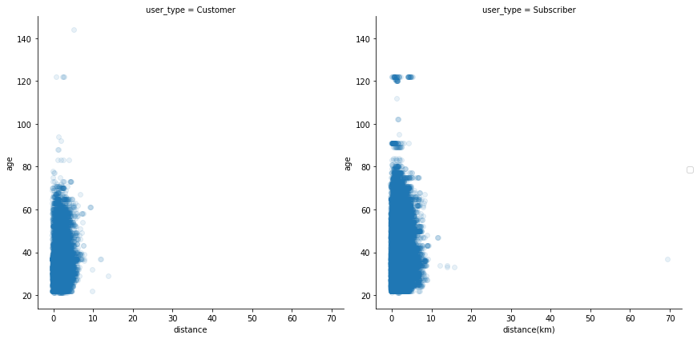

```python
# scatter plot of user_type, distance and age
plt.figure(figsize=[8, 5])

g = sb.FacetGrid(data= fordgobike, col ='user_type', size = 6)
g = g.map(sb.regplot, 'distance', 'age', fit_reg = False, scatter_kws={'alpha' : 0.1}, x_jitter = 0.3);
g.add_legend()
plt.xlabel('distance(km)')
plt.ylabel('age');
```

*What is the relationship between distance and duration_sec based on user_type?

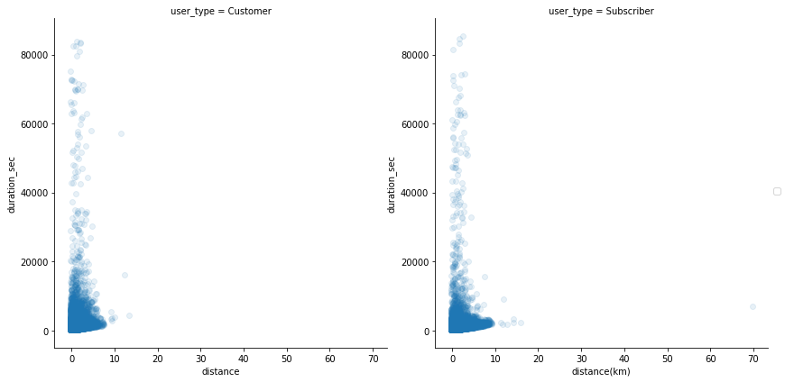

```python
# scatter plot of user_type, duration and age
plt.figure(figsize=[8, 5])

g = sb.FacetGrid(data= fordgobike, col ='user_type', size = 6)
g = g.map(sb.regplot, 'distance', 'duration_sec', fit_reg = False,scatter_kws={'alpha' : 0.1}, x_jitter = 0.3);
g.add_legend()
plt.xlabel('distance(km)')
plt.ylabel('duration_sec');
```

The distribution of time spent and distance covered are similar among subcribers and customers. There is an outlier for distance covered at 70km

- What is the relationship between duration_sec and age based on usertype?

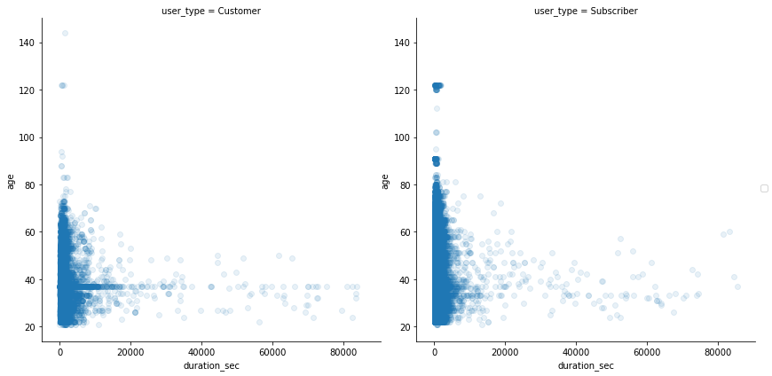

```python
# scatter plot of user_type, user type duration and age
plt.figure(figsize=[8, 5])

g = sb.FacetGrid(data= fordgobike, col ='user_type',size = 6)
g = g.map(sb.regplot, 'duration_sec', 'age', fit_reg = False,scatter_kws={'alpha' : 0.1}, x_jitter = 0.3);
g.add_legend()
plt.xlabel('duration_sec')
plt.ylabel('age');
```

Subcribers that spend longer time are within the age range of 30 to 60. Whereas customers that spend longer time are within the age range of 30 to 50. There is more elderly subscribers who spend very little time than customers. Subcribers and customers are mostly within the age range of 20 to 80 and spend between 0 to 10000 seconds cycling. There is a customer age outlier of 140 who spent close to 0 seconds.

- What is the relationship between distance covered and age based on member_gender?

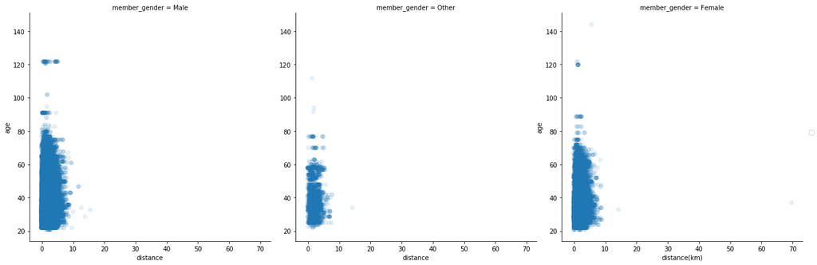

```python
# scatter plot of member_gender, distance and age
plt.figure(figsize=[8, 5])

g = sb.FacetGrid(data= fordgobike, col ='member_gender',size = 6)
g = g.map(sb.regplot, 'distance', 'age', fit_reg = False,scatter_kws={'alpha' : 0.1}, x_jitter = 0.3);
g.add_legend()
plt.xlabel('distance(km)')
plt.ylabel('age');
```

- What is the relationship between duration_sec and distance covered based on member_gender?

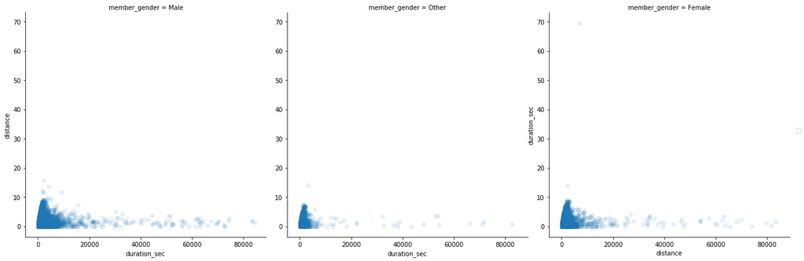

```python
# scatter plot of duration_syshem, distance and age
plt.figure(figsize=[8, 5])

g = sb.FacetGrid(data= fordgobike, col ='member_gender',size = 6)
g = g.map(sb.regplot, 'duration_sec', 'distance', fit_reg = False,scatter_kws={'alpha' : 0.1}, x_jitter = 0.3);
g.add_legend()
plt.xlabel('distance')
plt.ylabel('duration_sec');
```